# Practical Implementations of Principal Component Analysis

Nick Belgau, Oscar Hernandez Mata

2024-08-01

## The Math behind PCA

- Why SVD is widely used
- Overview of SVD algorithm
- Overview of Assumptions

**SVD is faster and more accurate than eigen-decomposition**

Although PCA is traditionally taught through eigen-decomposition of the covariance matrix, Singular Value Decomposition (SVD) is always used in practice.

- Numerical stability: No need to square the covariance matrix ($X^TX$) which can amplify errors; robust against ill-conditioned matrices.
- Efficient with large datasets: Directly decomposes the data without needing to compute and square the covariance matrix (Johnson and Wichern 2023).

[figure not shown]

sklearn.decomposition.PCA

[figure not shown]

stats::prcomp()

**SVD decomposition**
Ensure features are continuous and standardized ($\mu$ = 0, $\sigma$ = 1):
$$X = U \Sigma V^T$$
Each column of $𝑉$ represents a principal component (PC) which are orthogonal to each other and construct the new axes of maximum variance.

**Calculate explained variance by PC**
The diagonal singular value matrix $\Sigma$ corresponds to the strength of each PC:
$$\text{variance_explained} = \frac{\sigma_i^2}{\sum \sigma_i^2}$$

**Dimensionality reduction:**
- Select PCs: Based on cumulative explained variance target (95%).
- Truncate $V$: Select top PCs to reduce dimensions and transform $X$ into a new feature space.
$$X_{\text{transformed}} = X V_{\text{selected}}$$

The effectiveness of PCA relies on satisfying these points.

1. **Linearity**  
   PCA assumes that resulting principal components are linear combinations of the original variables. Nonlinear relationships may lead to low covariance values which can lead to an undervalued representation of their signficance.
2. **Continuous data**  
   PCA begins by standardizing the data, so the features should come from continuous distribution. Because the scale of measurement conveys information about the variance, categorical variables should be handled separately.
3. **Data standardization**
- Scaling standardizes the variance of each variable to ensure equal contributions.
- Mean-centering has a similar impact: ensuring that the principal components capture the true direction of maximum variance.
- Outliers can also distort the PCs, so they should be identified and handled appropriately.

## Application 1 - Analysis and Results

Load the required libaries:

### Dataset Description

```r
url <- "https://raw.githubusercontent.com/nickbelgau/STA6257_PCA/main/data/demographic/Alz_mortality_data_complete_with_state_csv.csv"
data_raw <- read_csv(url)

selected_columns <- c(
  "County", "State", "obesity_age_adj", "Smoking_Rate", "Diabetes", "Heart_Disease", "Cancer",  "Mercury_TPY", "Lead_TPY", "Food_index", "Poverty_Percent", "Atrazine_High_KG", "SUNLIGHT"
)

deep_south_states <- c("AL", "AR", "FL", "GA", "LA", "MS", "NC", "SC", "TN", "TX", "VA")

data <- data_raw %>%
  filter(State %in% deep_south_states) %>%
  select(all_of(selected_columns))

data <- data %>%
  select(-County, -State)
```

The dataset was filtered to analyze only selected variables for states in the deep south in the United States. The county and state columns were removed, creating 1 entire region on the dataset. Columns were selected to remove demographic fields related to gender, sex, and race and ambigious fields related to grouping.

The variables appear to be continuous because the data types are “numeric” with high cardinality. There are no nulls. It is clear that scaling and mean-centering will be needed.

```r
skim(data)
```

Data summary

| Name | data |
| --- | --- |
| Number of rows | 1143 |
| Number of columns | 11 |
| _______________________ |  |
| Column type frequency: |  |
| numeric | 11 |
| ________________________ |  |
| Group variables | None |

**Variable type: numeric**

| skim_variable | n_missing | complete_rate | mean | sd | p0 | p25 | p50 | p75 | p100 | hist |
| --- | --- | --- | --- | --- | --- | --- | --- | --- | --- | --- |
| obesity_age_adj | 0 | 1 | 31.65 | 3.76 | 19.00 | 29.16 | 31.26 | 33.95 | 46.92 | ▁▆▇▂▁ |
| Smoking_Rate | 0 | 1 | 25.06 | 3.56 | 10.72 | 22.94 | 25.62 | 27.68 | 32.86 | ▁▁▃▇▂ |
| Diabetes | 0 | 1 | 10.64 | 1.62 | 6.48 | 9.32 | 10.56 | 11.69 | 17.92 | ▂▇▆▁▁ |
| Heart_Disease | 0 | 1 | 126.68 | 38.46 | 41.20 | 99.90 | 120.10 | 146.85 | 279.20 | ▂▇▃▁▁ |
| Cancer | 0 | 1 | 187.78 | 26.55 | 75.33 | 170.25 | 188.26 | 204.40 | 370.64 | ▁▇▆▁▁ |
| Mercury_TPY | 0 | 1 | 0.02 | 0.07 | 0.00 | 0.00 | 0.00 | 0.00 | 0.94 | ▇▁▁▁▁ |
| Lead_TPY | 0 | 1 | 0.14 | 0.30 | 0.00 | 0.01 | 0.04 | 0.14 | 2.80 | ▇▁▁▁▁ |
| Food_index | 0 | 1 | 6.60 | 1.30 | 0.00 | 5.90 | 6.70 | 7.40 | 10.00 | ▁▁▃▇▁ |
| Poverty_Percent | 0 | 1 | 19.21 | 6.67 | 0.00 | 14.90 | 18.80 | 23.15 | 47.70 | ▁▇▇▁▁ |
| Atrazine_High_KG | 0 | 1 | 4531.16 | 24239.04 | 0.00 | 94.50 | 632.80 | 3480.10 | 768660.60 | ▇▁▁▁▁ |
| SUNLIGHT | 0 | 1 | 17689.04 | 1037.82 | 15389.96 | 16897.70 | 17723.25 | 18285.74 | 21671.87 | ▃▇▆▂▁ |

### Linarity Analysis

PCA works on the premise that principal components are linear combinations of the original features. Linearity between variables boosts PCA efficiency, while its absence may cause information loss. Statistical pairwise testing can automate the identification of non-linear relationships, providing a practical alternative to time-intensive visual inspection methods which is particularly helpful for large datasets.

The Harvey-Collier Test for Linearity fits a linear model to each variable pair, calculates recursive residuals, and conducts regression again on these residuals (Maureen, Oyinebifun, and Christopher 2022) (Harvey and Collier 1977). A significant nonzero slope in the residual regression indicates non-linearity, suggesting potential information loss in PCA.

```r
harvey_collier_test <- function(data, x, y) {
  formula <- as.formula(paste(y, "~", x))
  model <- lm(formula, data = data)
  test <- harvtest(model)
  p_value <- test$p.value
  return(signif(p_value, digits = 2))
}

variables <- names(data)
n <- length(variables)
p_matrix <- matrix(NA, n, n, dimnames = list(variables, variables))

for (i in 1:n) {
  for (j in 1:n) {
    if (i != j) {  # Avoid testing a variable against itself
      p_matrix[i, j] <- harvey_collier_test(data, variables[i], variables[j])
    }
  }
}
```

When the p-value is less than the signficance level, the test declares that the relationship is nonlinear. A heatmap of the p-values reveals which pairs are nonlinear with color-coding.

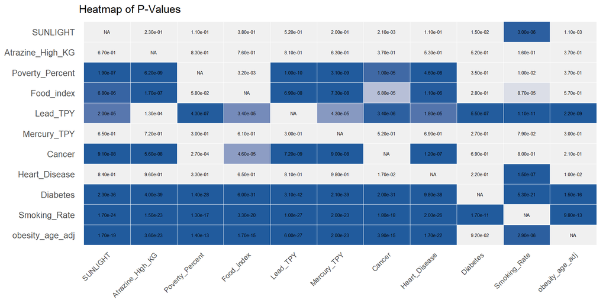

```r
library(ggplot2)

p_matrix_long <- melt(p_matrix)
names(p_matrix_long) <- c("Var1", "Var2", "p_value")

p_matrix_long$Var1 <- factor(p_matrix_long$Var1, levels = rev(unique(p_matrix_long$Var1)))

alpha = 0.0001

gradient_fill <- scale_fill_gradientn(
  colors = c("#215B9D", "#F0F0F0", "#F0F0F0"),
  values = scales::rescale(c(0, alpha, 1)),
  na.value = "#F0F0F0",  # Also set missing values to light grey
  guide = "colourbar"
)

ggplot(p_matrix_long, aes(Var1, Var2, fill= p_value)) +
  geom_tile(color = "white") +
  geom_text(aes(label = sprintf("%.2e", p_value)), color = "black", size = 2) +
  gradient_fill +
  theme_minimal() +
  theme(axis.text.x = element_text(angle = 45, hjust = 1, vjust = 1),
        axis.text.y = element_text(size = 10),
        axis.title.x = element_blank(),
        axis.title.y = element_blank(),
        panel.grid.major = element_blank(),
        panel.grid.minor = element_blank(),
        legend.position = "none") +
  labs(title = "Heatmap of P-Values")
```

The residual plot for a single pair that was flagged as nonlinear reveals why the Harvey-Collier Test declared nonlinearity. Although transformations can adjust linearity, they risk altering other variable relationships. Thus, no transformations were applied, acknowledging some information loss in PCA.

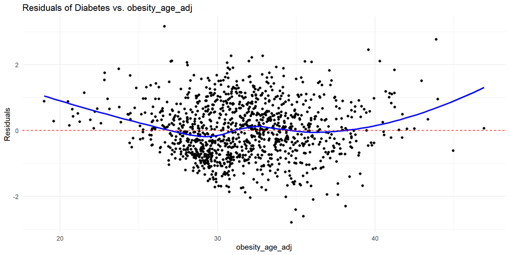

```r
data_residual <- as.data.frame(data)

data_residual$residuals <- residuals(lm(Diabetes ~ obesity_age_adj, data = data_residual))

ggplot(data_residual, aes(x = obesity_age_adj, y = residuals)) +
  geom_point() +
  geom_smooth(method = "loess", se = FALSE, color = "blue") +  # LOWESS curve
  geom_hline(yintercept = 0, linetype = "dashed", color = "red") +
  labs(title = "Residuals of Diabetes vs. obesity_age_adj",
       x = "obesity_age_adj", y = "Residuals") +
  theme_minimal()
```

### Outliers Analysis

Outliers can distort PCA results by disproportionately increasing variance, shifting the direction of principal components, and inflating eigenvalues. Before implementing outlier removal techniques, it is crucial to first examine the distribution to validate the rationale behind outlier exclusion. Although PCA does not require normality, a roughly normal distribution minimizes the impact from outliers. Non-normal data may undergo transformations like the Box-Cox to approximate normality. Assessing skewness and kurtosis offers practical insights into distribution characteristics.

```r
library(moments)

distribution_metrics <- function(df) {
  results <- data.frame(
    Kurtosis = sapply(data, kurtosis),
    Skewness = sapply(data, skewness)
  )
  results <- results[order(-results$Kurtosis),]
  return(results)
}

print(distribution_metrics(data))
```

```
                   Kurtosis   Skewness
Atrazine_High_KG 866.377802 27.6792372
Mercury_TPY       72.724213  7.4402444
Lead_TPY          34.286296  5.0314443
Cancer             5.489565  0.3562768
Food_index         4.878495 -0.8643685
Heart_Disease      3.867908  0.8405355
Poverty_Percent    3.795263  0.4674652
obesity_age_adj    3.680773  0.2879323
Smoking_Rate       3.531763 -0.7543274
Diabetes           3.344971  0.5427094
SUNLIGHT           2.974585  0.3380277
```

This analysis reveals columns with high kurtosis and skewness. Boxplots confirm that these are variables are right-skewed with numerous outliers, suggesting the need for transformation to improve PCA.

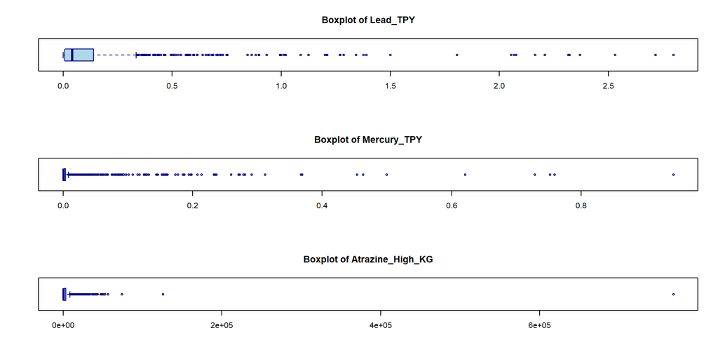

```r
columns_to_transform <- c("Lead_TPY", "Mercury_TPY", "Atrazine_High_KG")

par(mfrow=c(3, 1)) # format
for (col in columns_to_transform) {
  boxplot(
    data[[col]],
    horizontal=TRUE,
    main=paste("Boxplot of", col),
    col="lightblue",
    border="darkblue"
  )
}
```

The Box-Cox transformation is a robust statistical method that normalizes the data distribution, enhancing its suitability for PCA (“Compression of Spectral Data Using Box-Cox Transformation” 2014). It is considered best practice to apply such transformations to columns selectively rather than on the entirety of the dataset. Automating this process can be achieved by setting a kurtosis threshold.Additionally, negative values must be carefully managed to ensure the Box-Cox transformation is correctly implemented.

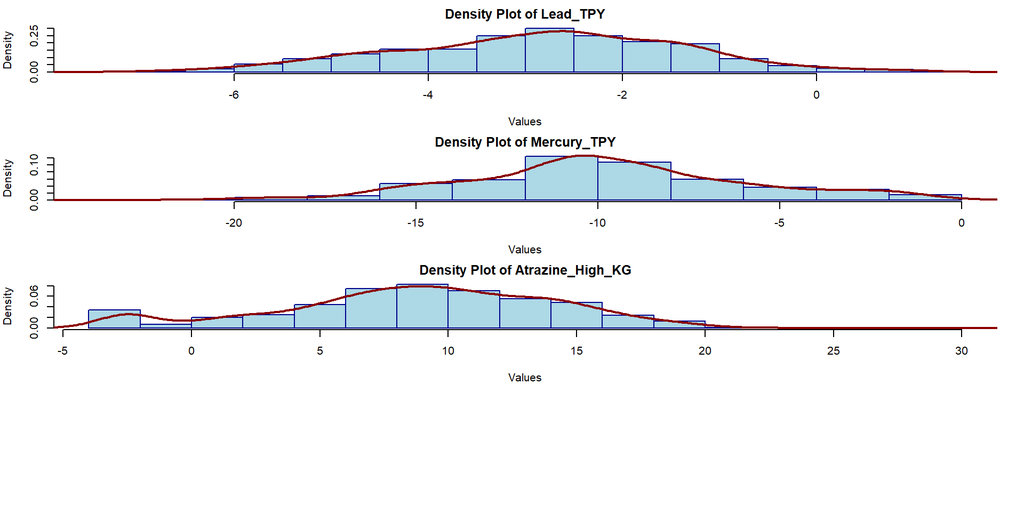

```r
library(MASS)

box_cox_transform <- function(df, columns) {
  transformed_df <- df
  lambdas <- list()
  for (col in columns) {
    col_data <- df[[col]]
    col_data[col_data <= 0] <- min(col_data[col_data > 0]) / 2
    bc <- boxcox(col_data ~ 1, plotit=FALSE)
    lambda <- bc$x[which.max(bc$y)]
    transformed_df[[col]] <- (col_data^lambda - 1) / lambda
    lambdas[[col]] <- lambda
  }
  return(list(transformed_df, lambdas))
}

result <- box_cox_transform(data, columns_to_transform)
data_transform <- result[[1]]
lambdas <- result[[2]]

par(mfrow = c(length(columns_to_transform) + 1, 1), mar = c(4, 4, 2, 2))
for (i in columns_to_transform) {
  hist(data_transform[[i]], probability = TRUE, main = paste("Density Plot of", i), xlab = "Values", col = "lightblue", border = "darkblue")
  lines(density(data_transform[[i]]), col = "darkred", lwd = 2)
}
```

The transformations create an approximate bell-shaped distribution, reducing outlier effects. Minor power adjustments, indicated by lambda values, enhance PCA effectiveness without the need for manual outlier removal.

```r
lambda_df <- data.frame(
  Lambda = unlist(lambdas)
)
print(lambda_df)
```

```
                 Lambda
Lead_TPY            0.1
Mercury_TPY        -0.1
Atrazine_High_KG    0.1
```

### Correlation Analysis

A heatmap of the correlation matrix was analyzed to identify highly correlated variables, indicating potential multicollinearity within the dataset. By applying PCA, correlated variables can be transformed into orthogonal components which eliminate multicollinearity. This transformation ensures each principal component captures unique variance, improving the clarity and reliability of modeling.

```r
library(corrplot)

cor_matrix <- cor(data, use = "complete.obs")  # Handle missing values

color_palette <- colorRampPalette(c("#215B9D", "#DCE6F1", "#215B9D"))(200) # blue #215B9D

corrplot(abs(cor_matrix), method = "color",
        #  type = "lower",
         order = "hclust",
         addCoef.col = "#36454F",
         number.cex = 0.50,
         tl.col = "black",
         tl.srt = 45,  # No rotation for text labels
        #  tl.pos = "d",  # Position text labels at the bottom (x-axis)
         cl.pos="n",
         col = color_palette,
         bg = "white"
)
```

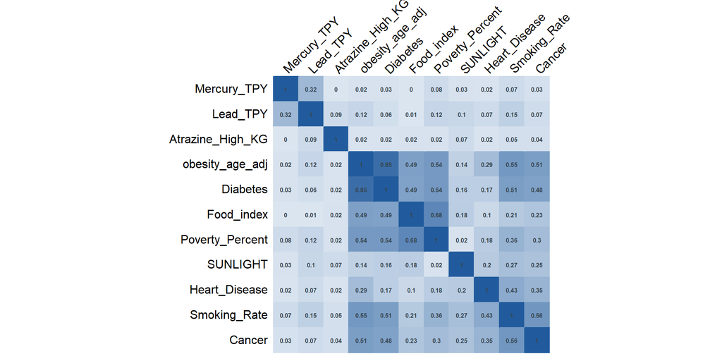

Amin, R. W., E. M. Yacko, and R. P. Guttmann. 2018. “Geographic Clusters of Alzheimer’s Disease Mortality Rates in the USA: 2008-2012.” *Journal of Prevention of Alzheimer’s Disease (JPAD)* 3.

“Compression of Spectral Data Using Box-Cox Transformation.” 2014. *Color Research & Application* 39 (2). https://doi.org/10.1002/col.21771.

Harvey, A., and P. Collier. 1977. “Testing for Functional Misspecification in Regression Analysis.” *Journal of Econometrics* 6: 103–19.

Johnson, Richard, and Dean Wichern. 2023. *Applied Multivariate Statistical Analysis*. Pearson.

Maureen, Nwakuya Tobechukwu, Biu Emmanuel Oyinebifun, and Ekwe Christopher. 2022. “Investigating Instability of Regression Parameters and Structural Breaks in Nigerian Economic Data from 1984 to 2019.” *International Journal of Mathematics Trends and Technology* 68 (12): 67–73. https://doi.org/10.14445/22315373/IJMTT-V68I12P509.

Tejada-Vera, Betzaida. 2013. “Mortality from Alzheimer’s Disease in the United States: Data for 2000 and 2010.” *NCHS Data Brief*, no. 116: 1–8.